# Supervised Learning Case: Predicting potential customers for a personal loan in a financial institution

### Random Forest

Just as trees can be grouped as a forest, a number of classification trees can be combined into a collection known as Random Forest. This represents one of the most powerful Machine Learning classifiers, remarkably efficient and easy to use. The power of this algorithm comes from a collection of smaller and simple trees that together reflect the data’s complexity. Each of the forest’s trees is diverse and may reflect subtle patterns in the outcome to be modeled. Generating this diversity is the key to building powerful decision tree forests.

The algorithm allocate to each tree a random subset of the data, one may receive a vastly different training set than another, that is known as the bagging ensemble method.

The figure below (extracted from [**this article**](https://www.analyticsvidhya.com/blog/2021/06/understanding-random-forest/)) let understand in a clear way how the Random Forest algorithm works.

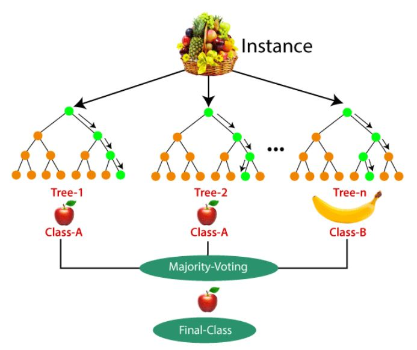

As we can see groups of classification trees can be combined into an **ensemble** that generates a single prediction by allowing the trees to “vote” on the outcome.

```r
rf<-randomForest(Personal.Loan~ ., data=banktrain,
                 mtry=sqrt(11), #number of predictors per tree. It is given by the square root of the n independent features
                 method="class",
                 importance=TRUE)

predrf <- predict(rf, banktest)
```

Now we can see how important is each variable in classifying the data modeling the Random Forest algorithm. The **Mean Decrease Accuracy** plot expresses how much accuracy the model losses by excluding each variable. The more the accuracy suffers, the more important the variable is for the successful classification. The **Mean Decrease in Gini Coefficient** is a measure of how each variable contributes to the homogeneity of the nodes and leaves in the resulting random forest. The higher the value of mean decrease accuracy or mean decrease Gini score, the higher the importance of the variable in the model.

In the figure below we can look how the variables are presented from descending importance for each metric.

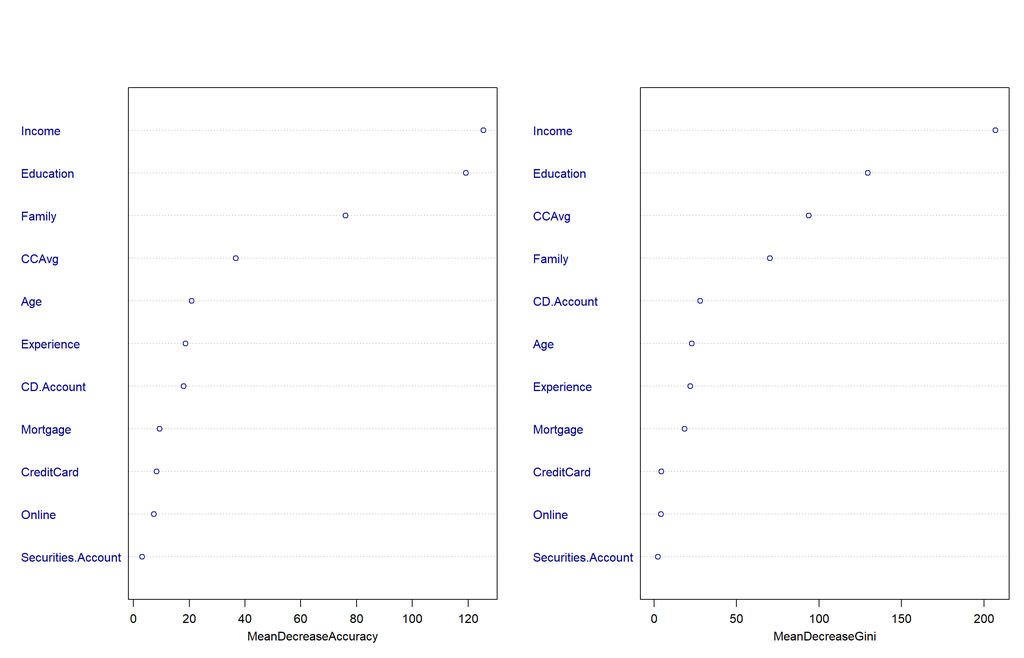

**Figure 10.** Random Forest Importance of Variables plot.

```r
# Plot  importance
varImpPlot(rf, main="",col="dark blue")
```

As we can see most important variables are Income and Education. As I showed on the Exploratory Data Analysis both variables are correlated. Also is interesting to find out Family is also an interesting variable which can affect the decision of a customer to take a loan, which is exactly the opposite of the hypotehsis I set on EDA.

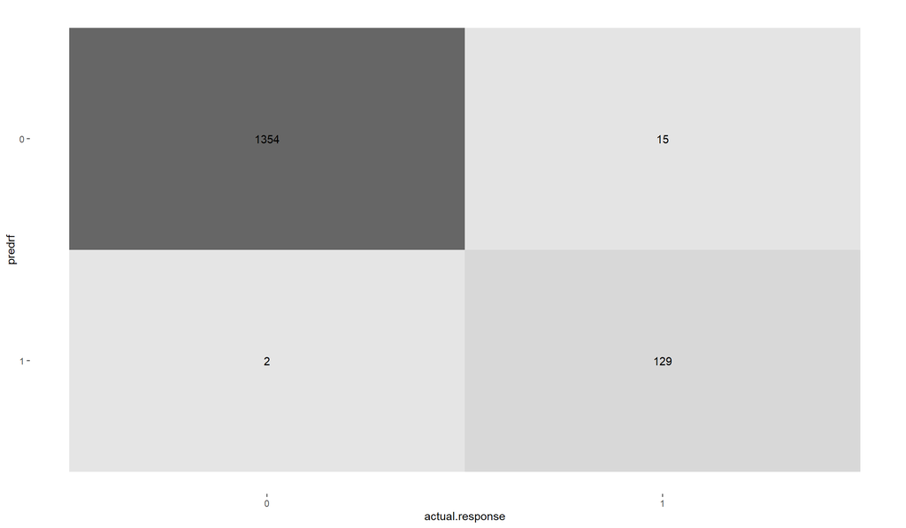

**Figure 11.** Confusion matrix for Random Forest Model.

```r
#Create confusion matrix
outcomesrf <- table(predrf, actual.response)
confusionrf <- conf_mat(outcomesrf)

#Plot confusion matrix
autoplot(confusionrf, type="heatmap")
```

```r
#Performance metrics
performancerf <- summary(confusionrf, event_level="second") %>% select(.metric, .estimate)
```

### K-nearest Neighbor

K-NN algorithm predicts the correct class for the test data by calculating the distance between the test data and all the training points, then selects the K number of points which is closest to the test data.

The K-NN algorithm calculates the probability of the test data belonging to the classes of ‘K’ training data and class holds the highest probability will be selected. In the case of regression, the value is the mean of the ‘K’ selected training points.

There’s a simple graphical explanation I extracted from **this Medium Article.**

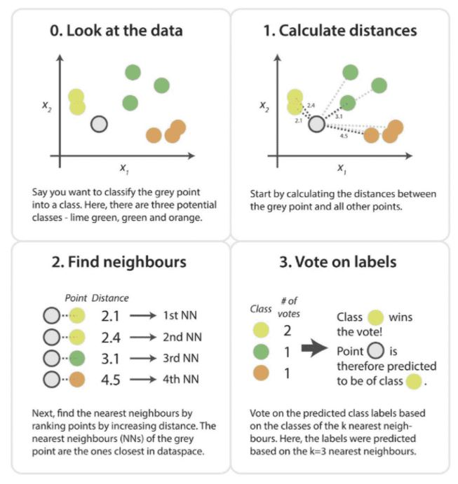

The k variable specifies the number of neighbors to consider when making the classification, for hence, choosing the k value is very critical. A really small value of k means that noise will have a higher influence on the result and large value make it computationally expensive and kinda defeats the basic philosophy behind KNN (that points that are near might have similar densities or classes). There is not an universal rule to select k, however, a simple approach to select k is set k = n^(1/2), being n the number of variables we are classifying.

Now we know how the K-NN algorithm works, let’s train and evaluate the model.

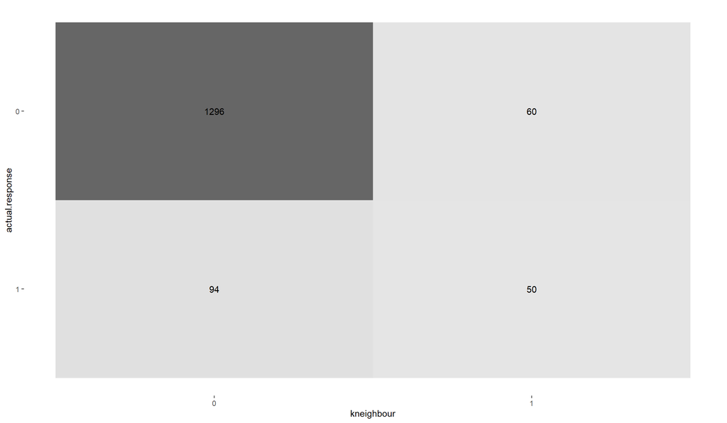

**Figure 12.** Confusion matrix for K-Nearest Neighbor Model.

```r
#Train model
kneighbour<-knn(train = banktrain[,-c(6, 8)], test = banktest[,-c(6,8)], cl= factor(banktrain$Personal.Loan), k=sqrt(10), prob=TRUE)
#Knn only works with numeric variables so we eliminate the categorical from the test/training data.

#Confusion Matrix

tabknn<-table(actual.response,kneighbour)
confusionknn <- conf_mat(tabknn)

#Plot confusion matrix
autoplot(confusionknn, type="heatmap")
```

```r
#Performance metrics
performanceknn <- summary(confusionknn, event_level="second") %>% select(.metric, .estimate)
```

# **Evaluation & Selection of Best Model**

Models can be evaluated using multiple metrics. However, the right choice of an evaluation metric is crucial and often depends upon the problem that is being solved. In this case, as our **business objective** is to predict prospective loan customers, I am going to focus on these three metrics: **Accuracy**, **Specificity** and **Sensibility**.

**Accuracy** is the simplest metric and can be defined as the number of test cases correctly classified divided by the total number of test cases.

$$Accuracy~=~\frac{True~Positives+True~Negatives}{True~Positives+True~Negatives+False~Positives+False~Negatives}$$
Definitely we look for an accurate model able to predict in almost all the cases the prospective customers and direct all the efforts and marketing dollars to those prospective loan customers.

**Sensitivity** tells us the number of positive cases correctly identified out of the total number of positive cases. Also know as recall or true positive rate.

$$Sensitivity~=~\frac{True~Positives}{True~Positves+False~Negatives}$$
**Specificity** is the proportion of actual negatives which got predicted as the negative (or true negative). Also known as true negative rate.

$$Specificity~=~\frac{True~Negatives}{False~Positives+True~Negatives}$$
As we want to deploy an accurate model we also want to be make sure the true prospective customer are being correctly classified rather than the ones are not. By this premise we will focus on choosing models with a better performance in Sensitivity than Specificity.

However, best way to evaluate Sensitivity and Specificity measures is by ploting the ROC curve and calculating Area under ROC curve (AUC), used to determine the model performance. The **Receiver Operator Characteristic (ROC)** plots out the Sensitivity and Specificity for every possible decision rule cutoff between 0 and 1 for a model in different probability thresholds.

```r
#Getting the three metrics to evaluate
accuracy <- rbind(performancelm[1,2], performancedt[1,2], performancerf[1,2], performanceknn[1,2])
sens <- rbind(performancelm[3,2], performancedt[3,2], performancerf[3,2], performanceknn[3,2])
spec <- rbind(performancelm[4,2], performancedt[4,2], performancerf[4,2], performanceknn[4,2])

#Comparative table
models <- c("Logistic Regression","Decision Tree","Random Forest", "K-NN")
seleccion <- cbind(models,accuracy, sens, spec)
colnames(seleccion) <- c("Models", "Accuracy", "Sensibility","Specificity")
kable(seleccion,  caption="**Table 7.** Performance metrics for each model trained.", digits=3)
```

**Table 7.** Performance metrics for each model trained.

| Models | Accuracy | Sensibility | Specificity |
| --- | --- | --- | --- |
| Logistic Regression | 0.969 | 0.792 | 0.987 |
| Decision Tree | 0.978 | 0.991 | 0.977 |
| Random Forest | 0.989 | 0.896 | 0.999 |
| K-NN | 0.897 | 0.455 | 0.932 |

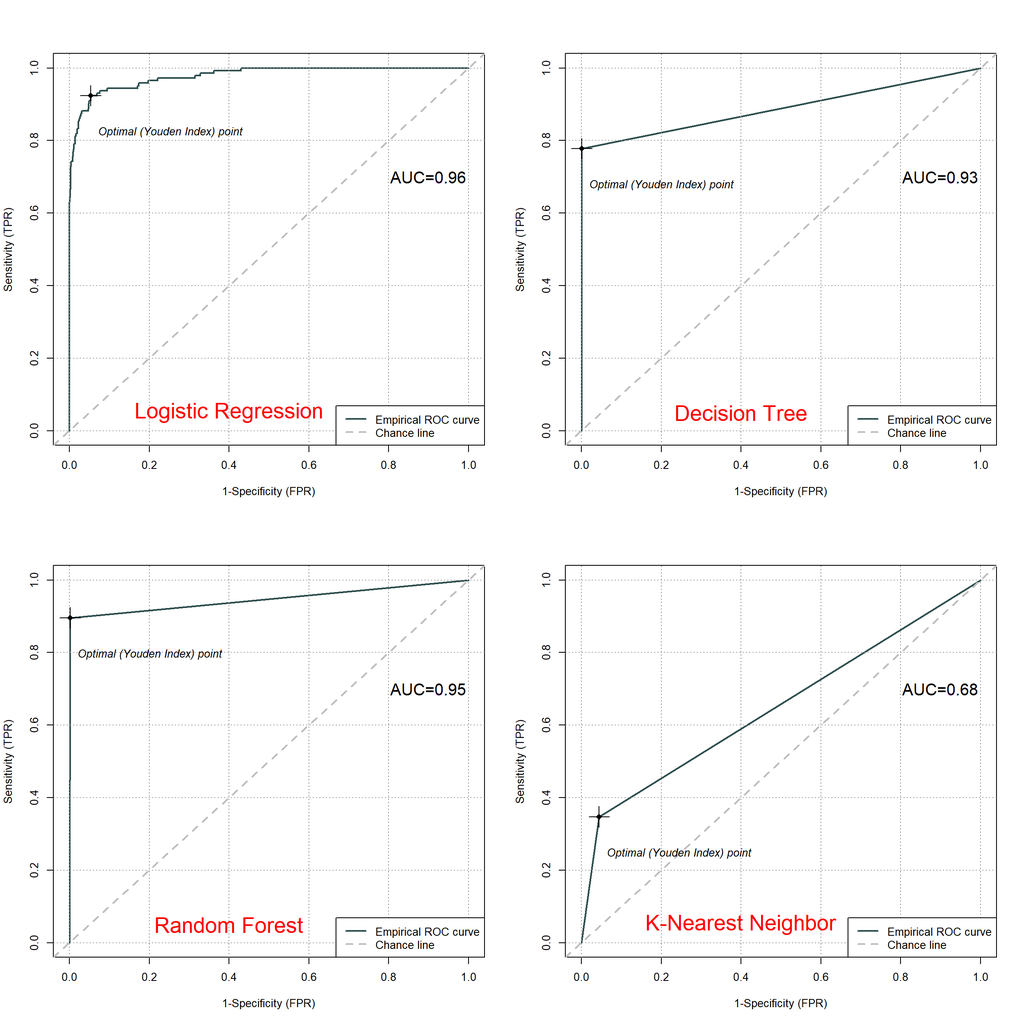

**Figure 13.** ROC Curves for classification models trained/tested.

```r
#First I create ROC objects for every model tested
ROCit_lm <- rocit(score=pred.logit.test, class=actual.response)
ROCit_dt <- rocit(score=as.numeric(predt_pruned), class=actual.response)
ROCit_rf <- rocit(score=as.numeric(predrf), class=actual.response)
ROCit_knn <- rocit(score=as.numeric(kneighbour), class=actual.response)

#Then I plot the ROC curve. Also I added the AUC extracting it from the ROCit object created in the previous step
par(mfrow=c(2,2))
plot(ROCit_lm)
text(0.9, 0.7, c("AUC=0.96"), cex=1.5)
text(0.4, 0.05, c("Logistic Regression"), cex=2, col="red")
plot(ROCit_dt)
text(0.9, 0.7, c("AUC=0.93"), cex=1.5)
text(0.4, 0.05, c("Decision Tree"), cex=2, col="red")
plot(ROCit_rf)
text(0.9, 0.7, c("AUC=0.95"), cex=1.5)
text(0.4, 0.05, c("Random Forest"), cex=2, col="red")
plot(ROCit_knn)
text(0.9, 0.7, c("AUC=0.68"), cex=1.5)
text(0.4, 0.05, c("K-Nearest Neighbor"), cex=2, col="red")
```

First we notice the performance of K-NN does not seems really appropriate, despite has good specificity and accuracy metrics (but lower than the other models), sensibility has a poor value for our expectations. We notice Random Forest and Decision Tree’s accuracy are the best compared with the other models. Checking the ROC curve it seems like the Logistic Regression has the best performance fit by evaluating the AUC (0.96). However, as we follow the rule to look for a model with a good sensibility metric keeping in mind the reasoning mentioned previously above, the sensibility performance in Logistic Regression is not good for our business purposes.

Finally the election would be between Random Forest and Decision Tree models..

# **Conclusions & Recommendations**

- Model choose to deploy is Decision Tree. It has an accuracy of 97.8% and AUC=0.93, that means it predicts in valid and trustful way for our purposes.
- The most important variables which defines if a customer is more likely to get a personal loan are: Income, Education, Family size and Average Credit Card Monthly Spent.
- Our **ideal candidate** and for hence the one Business Development and Marketing Teams should focus are customers who has a salary around 80-200k$ per year, is graduate or advanced/professional, has a family size equal or +3 people, and spend around 2.5-5k$ monthly on credit cards.